# Demonstração ao vivo — Header

Bloco 4 do minicurso

Autor

Julia Apolonio

Data de Publicação

18 de agosto de 2026

**DicaComo acompanhar**

A maior parte da demonstração acontece **no header YAML acima**, não nos chunks. Edite uma opção, salve, renderize — e mostre a diferença. Coloquei opções de exploração em tópicos nesse documento

# 1 Header básico

O header atual já tem `title`, `subtitle`, `author`, `date` e `lang`.

- Mudar o autor
- Mudar a data

## 1.1 Adicionando autoria completa

- Trocar a linha `author: "Julia Apolonio"` por:

```yaml
author:
  - name: "Julia Apolonio"
    affiliation: "UFRN"
```

# 2 `toc`, `number-sections` e afins

- Ligar e desligar toc
- Ligar e desligar number-sections
- Mudar o tema (cosmo, darkly)
- Adicionar anchor sections
- Mudar o code fold e code tools:

```yaml
  html:
    code-fold: true
    code-tools: true
```

Como visto na sessão Seção 2, a numeração existe implicitamente e o crossref continua funcionando…

# 3 `embed-resources`

```yaml
embed-resources: true
```

- Demonstrar embed resources

Imagem gerada no próprio relatório não vai ser aberta se não tiver o embed-resources habilitado

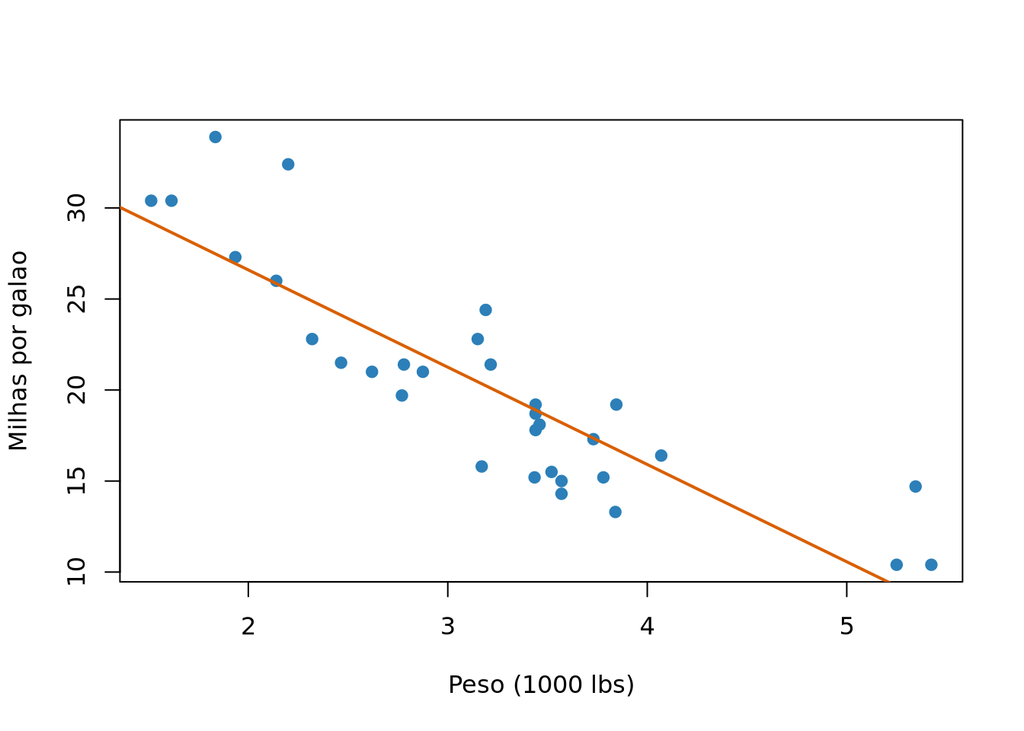

```r
plot(mtcars$wt, mtcars$mpg,
     pch = 19, col = "#2C7FB8",
     xlab = "Peso (1000 lbs)", ylab = "Milhas por galao")
abline(lm(mpg ~ wt, data = mtcars), col = "#D95F02", lwd = 2)
```

# 4 Cache

- Testar a velocidade de renderização com e sem o cache
- Testar mudar o valor do sleep com o cache habilitado

```r
Sys.sleep(15)
resultado <- mean(rnorm(1e6))
resultado
```

```
[1] -0.000521437
```

## 4.1 O `dependson`

```r
dados <- rnorm(90)
```

```r
mean(dados)
```

```
[1] 0.2365394
```

- Tirar o cache do carrega-dados e ver o que acontece com usa-dados

# 5 Header do documento vs header do chunk

O mesmo nome de opção pode estar em dois lugares — e o mais específico sempre vence.

- Adicionar isso no header do documento e ver o que acontece com o chunk seguinte

```yaml
execute:
  echo: false
```

```r
# Mesmo com echo: false no header do documento,
# ESTE código aparece — porque #| echo: true manda mais.
1 + 1
```

```
[1] 2
```

# 6 Opções de execução — exemplos

## 6.1 `eval`: executa ou não o código

```r
# roda e mostra o resultado (comportamento padrão)
2 + 2
```

```
[1] 4
```

```r
# aparece o código, mas NÃO executa — útil para comandos de cluster
2 + 2
```

## 6.2 `echo`: mostra ou não o código-fonte

```r
# mostra o código E o resultado (padrão)
mean(1:10)
```

```
[1] 5.5
```

```
[1] 5.5
```

## 6.3 `output`: mostra ou não o resultado

```r
# mostra o código E o resultado (padrão)
summary(1:10)
```

```
   Min. 1st Qu.  Median    Mean 3rd Qu.    Max.
   1.00    3.25    5.50    5.50    7.75   10.00
```

```r
# mostra o código, mas ESCONDE o resultado
summary(1:10)
```

## 6.4 `warning`: mostra ou não avisos do R

```r
# o aviso abaixo APARECE no documento
as.numeric("abc")
```

```
Warning: NAs introduced by coercion
```

```
[1] NA
```

```r
# o mesmo aviso fica ESCONDIDO
as.numeric("abc")
```

```
[1] NA
```

## 6.5 `error: true`: continua renderizando mesmo com erro

```r
# sem error: true, este chunk PARARIA a renderização inteira
stop("Isto é um erro proposital.")
```

```
Error:
! Isto é um erro proposital.
```

```r
# a prova de que a renderização continuou depois do erro acima
"Chegamos até aqui."
```

```
[1] "Chegamos até aqui."
```

## 6.6 `include: false`: executa, mas não mostra NADA

O valor de `x` fica disponível para os chunks seguintes, mesmo sem aparecer no documento: 456.